# Tidymodels: Recipes & Classification Models

Learn how to build a classification model with tidymodels

Prof. Dr. Jan Kirenz

*The following content is taken from the excellent [tidymodels documentation](https://www.tidymodels.org/start/recipes/).*

In this tutorial, we’ll explore a tidymodels package, `recipes`, which is designed to help you preprocess your data before training your model.

Recipes are built as a series of preprocessing steps, such as:

- converting qualitative predictors to indicator variables (also known as dummy variables),
- transforming data to be on a different scale (e.g., taking the logarithm of a variable),
- transforming whole groups of predictors together,
- extracting key features from raw variables (e.g., getting the day of the week out of a date variable),

and so on. If you are familiar with R’s formula interface, a lot of this might sound familiar and like what a formula already does. Recipes can be used to do many of the same things, but they have a much wider range of possibilities. This article shows how to use recipes for modeling.

To use the code in this tutorial, you will need to install the following packages:

- `nycflights13`,
- `skimr`, and
- `tidymodels.`

```r
library(tidymodels)
# for flight data:
library(nycflights13)
# for variable summaries:
library(skimr)
```

# 1 New York city flight data

Let’s use the `nycflights13` data to predict whether a plane arrives more than 30 minutes late. This data set contains information on 325,819 flights departing near New York City in 2013. Furthermore, it contains weather data (hourly meterological data for LGA, JFK and EWR).

Let’s start by loading the data and making a few changes to the variables:

```r
flight_data_all <-
  flights %>%
  mutate(
    # Convert the arrival delay to a factor
    arr_delay = ifelse(arr_delay >= 30,
                       "late",
                       "on_time"),
    arr_delay = factor(arr_delay),
    # We will use the date (not date-time)
    # in the recipe below
    date = as.Date(time_hour)
  ) %>%
  # Include  weather data
  inner_join(weather, by = c("origin", "time_hour")) %>%
  # Only retain the specific columns we will use
  select(dep_time, flight, origin,
         dest, air_time, distance,
         carrier, date, arr_delay, time_hour) %>%
  # Exclude missing data
  na.omit() %>%
  # For creating models, it is
  # better to have qualitative columns
  # encoded as factors (instead of character strings)
  mutate(across(where(is.character), as.factor))
```

To speed up later calculations we only use a sample of the data:

```r
flight_data <- sample_n(flight_data_all,
                        10000)
```

We can see that about 17% of the flights in this data set arrived more than 30 minutes late:

```r
flight_data %>%
  count(arr_delay) %>%
  mutate(prop = n/sum(n))
```

| arr_delay | n | prop |
| --- | --- | --- |
| late | 1648 | 0.1648 |
| on_time | 8352 | 0.8352 |

Before we start building up our recipe, let’s take a quick look at a few specific variables that will be important for both preprocessing and modeling.

```r
glimpse(flight_data)
```

```
## Rows: 10,000
## Columns: 10
## $ dep_time  <int> 927, 1104, 1027, 1822, 957, 1643, 2143, 716, 1539, 1028, 11…
## $ flight    <int> 1281, 1031, 2343, 5268, 1110, 1636, 5489, 15, 765, 179, 466…
## $ origin    <fct> EWR, LGA, EWR, LGA, EWR, EWR, LGA, EWR, EWR, JFK, EWR, EWR,…
## $ dest      <fct> SFO, DTW, ATL, CLT, LAS, ORD, CHO, SEA, DEN, SFO, JAX, RDU,…
## $ air_time  <dbl> 348, 76, 114, 72, 347, 115, 51, 342, 211, 367, 109, 62, 277…
## $ distance  <dbl> 2565, 502, 746, 544, 2227, 719, 305, 2402, 1605, 2586, 820,…
## $ carrier   <fct> UA, DL, DL, EV, UA, UA, EV, AS, UA, AA, EV, EV, DL, AA, UA,…
## $ date      <date> 2013-06-26, 2013-03-21, 2013-08-20, 2013-09-30, 2013-11-21…
## $ arr_delay <fct> late, on_time, on_time, on_time, on_time, on_time, on_time,…
## $ time_hour <dttm> 2013-06-26 09:00:00, 2013-03-21 11:00:00, 2013-08-20 10:00…
```

Second, there are two variables that we don’t want to use as predictors in our model, but that we would like to retain as identification variables that can be used to troubleshoot poorly predicted data points. These are flight, a numeric value, and time_hour, a date-time value.

```r
flight_data %>%
  skimr::skim(dest, carrier)
```

Data summary

| Name | Piped data |
| --- | --- |
| Number of rows | 10000 |
| Number of columns | 10 |
| _______________________ |  |
| Column type frequency: |  |
| factor | 2 |
| ________________________ |  |
| Group variables | None |

**Variable type: factor**

| skim_variable | n_missing | complete_rate | ordered | n_unique | top_counts |
| --- | --- | --- | --- | --- | --- |
| dest | 0 | 1 | FALSE | 99 | ATL: 532, ORD: 524, LAX: 474, BOS: 454 |
| carrier | 0 | 1 | FALSE | 16 | UA: 1816, B6: 1597, EV: 1587, DL: 1472 |

Because we’ll be using a logistic regression model in this tutorial, the variables `dest` and `carrier` will be converted to dummy variables.

However, some of these values do not occur very frequently and this could complicate our analysis. We’ll discuss specific steps later in this tutorial that we can add to our recipe to address this issue before modeling.

# 2 Data splitting

To get started, let’s split this single dataset into two: a training set and a testing set. We’ll keep most of the rows in the original dataset (subset chosen randomly) in the training set. The training data will be used to fit the model, and the testing set will be used to measure model performance.

To do this, we can use the `rsample` package (included in `tidymodels`) to create an object that contains the information on how to split the data, and then two more rsample functions to create data frames for the training and testing sets:

```r
# Fix the random numbers by setting the seed
# This enables the analysis to be reproducible
# when random numbers are used
set.seed(555)

# Put 3/4 of the data into the training set
data_split <- initial_split(flight_data,
                            prop = 3/4)

# Create data frames for the two sets:
train_data <- training(data_split)
test_data  <- testing(data_split)
```

# 3 Create recipe and roles

To get started, let’s create a recipe for a classification model. Before training the models, we can use a recipe to create a few new predictors and conduct some preprocessing required by the model.

Let’s initiate a new recipe:

```r
flights_rec <-
  recipe(arr_delay ~ .,
         data = train_data)
```

The `recipe()` function as we used it here has two arguments:

- *A formula*. Any variable on the left-hand side of the tilde (~) is considered the model outcome (here, `arr_delay`). On the right-hand side of the tilde are the predictors. Variables may be listed by name, or you can use the dot (.) to indicate all other variables as predictors.
- *The data*. A recipe is associated with the data set used to create the model. This will typically be the training set, so `data = train_data` here. Naming a data set doesn’t actually change the data itself; it is only used to catalog the names of the variables and their types, like factors, integers, dates, etc.

Now we can add roles to this recipe. We can use the `update_role()` function to let recipes know that `flight` and `time_hour` are variables with a custom role that we call “ID” (a role can have any character value). Whereas our formula included all variables in the training set other than `arr_delay` as predictors, this tells the recipe to keep these two variables but not use them as either outcomes or predictors.

```r
flights_rec <-
  recipe(arr_delay ~ ., data = train_data) %>%
  update_role(flight,
              time_hour,
              new_role = "ID")
```

This step of adding roles to a recipe is optional; the purpose of using it here is that those two variables can be retained in the data but not included in the model. This can be convenient when, after the model is fit, we want to investigate some poorly predicted value. These ID columns will be available and can be used to try to understand what went wrong.

To get the current set of variables and roles, use the summary() function:

```r
summary(flights_rec)
```

| variable | type | role | source |
| --- | --- | --- | --- |
| dep_time | numeric | predictor | original |
| flight | numeric | ID | original |
| origin | nominal | predictor | original |
| dest | nominal | predictor | original |
| air_time | numeric | predictor | original |
| distance | numeric | predictor | original |
| carrier | nominal | predictor | original |
| date | date | predictor | original |
| time_hour | date | ID | original |
| arr_delay | nominal | outcome | original |

# 4 Create features

Now we can start adding steps onto our recipe using the pipe operator.

Perhaps it is reasonable for the `date` of the flight to have an effect on the likelihood of a late arrival. A little bit of feature engineering might go a long way to improving our model. How should the date be encoded into the model? The date column has an R date object so including that column “as is” will mean that the model will convert it to a numeric format equal to the number of days after a reference date:

```r
flight_data %>%
  distinct(date) %>%
  mutate(numeric_date = as.numeric(date))
```

| date | numeric_date |
| --- | --- |
| 2013-06-26 | 15882 |
| 2013-03-21 | 15785 |
| 2013-08-20 | 15937 |
| 2013-09-30 | 15978 |
| 2013-11-21 | 16030 |
| 2013-06-08 | 15864 |
| 2013-08-02 | 15919 |
| 2013-05-25 | 15850 |
| 2013-11-22 | 16031 |
| 2013-05-10 | 15835 |

[output cut: 354 more lines]

It’s possible that the numeric date variable is a good option for modeling. However, it might be better to add model terms derived from the date that have a better potential to be important to the model. For example, we could derive the following meaningful features from the single date variable:

- the day of the week,
- the month, and
- whether or not the date corresponds to a holiday.

Let’s do all three of these by adding steps to our recipe:

```r
flights_rec <-
  recipe(arr_delay ~ .,
         data = train_data) %>%
  update_role(flight,
              time_hour,
              new_role = "ID") %>%
  step_date(date,
            features = c("dow", "month")) %>%
  step_holiday(date,
               holidays = timeDate::listHolidays("US")) %>%
  step_rm(date)
```

What do each of these steps do?

- With `step_date()`, we created two new factor columns with the appropriate day of the week (dow) and the month.
- With `step_holiday()`, we created a binary variable indicating whether the current date is a holiday or not. The argument value of `timeDate::listHolidays("US"`) uses the timeDate package to list the 17 standard US holidays.
- With `step_rm()`, we remove the original date variable since we no longer want it in the model.

Next, we’ll turn our attention to the variable types of our predictors. Because we plan to train a classifiaction model, we know that predictors will ultimately need to be numeric, as opposed to factor variables. In other words, there may be a difference in how we store our data (in factors inside a data frame), and how the underlying equations require them (a purely numeric matrix).

For factors like `dest` and `origin`, standard practice is to convert them into *dummy* or indicator variables to make them numeric. These are binary values for each level of the factor. For example, our origin variable has values of “EWR”, “JFK”, and “LGA”. The standard dummy variable encoding, shown below, will create two numeric columns of the data that are 1 when the originating airport is “JFK” or “LGA” and zero otherwise, respectively.

| ORIGIN | ORIGIN_JFK | ORIGIN_LGA |
| --- | --- | --- |
| EWR | 0 | 0 |
| JFK | 1 | 0 |
| LGA | 0 | 1 |

But, unlike the standard model formula methods in R, a recipe does not automatically create these dummy variables for you; you’ll need to tell your recipe to add this step. This is for two reasons. First, many models do not require numeric predictors, so dummy variables may not always be preferred. Second, recipes can also be used for purposes outside of modeling, where non-dummy versions of the variables may work better. For example, you may want to make a table or a plot with a variable as a single factor. For those reasons, you need to explicitly tell recipes to create dummy variables using step_dummy():

```r
flights_rec <-
  recipe(arr_delay ~ .,
         data = train_data) %>%
  update_role(flight,
              time_hour,
              new_role = "ID") %>%
  step_date(date,
            features = c("dow", "month")) %>%
  step_holiday(date,
               holidays = timeDate::listHolidays("US")) %>%
  step_rm(date) %>%
  step_dummy(all_nominal(), -all_outcomes())
```

Here, we did something different than before: instead of applying a step to an individual variable, we used selectors to apply this recipe step to several variables at once.

- The first selector, `all_nominal()`, selects all variables that are either factors or characters.
- The second selector, `-all_outcomes()` removes any outcome variables from this recipe step.

With these two selectors together, our recipe step above translates to:

> Create dummy variables for all of the factor or character columns unless they are outcomes.

At this stage in the recipe, this step selects the `origin`, `dest`, and `carrier` variables. It also includes two new variables, `date_dow` and `date_month`, that were created by the earlier `step_date()`.

More generally, the recipe selectors mean that you don’t always have to apply steps to individual variables one at a time. Since a recipe knows the variable type and role of each column, they can also be selected (or dropped) using this information.

Note that since `carrier` and `dest` have some infrequently occurring values, it is possible that dummy variables might be created for values that don’t exist in the training set. For example, there could be destinations that are only in the test set. The function [`anti_join()`](https://dplyr.tidyverse.org/reference/join.html) returns all rows from x (test_data) where there are not matching values in y (train_data), keeping just columns from x.:

```r
test_data %>%
  distinct(dest) %>%
  anti_join(train_data)
```

| dest |
| --- |
| JAC |
| EYW |

When the recipe is applied to the training set, a column could contain only zeros. This is a “*zero-variance predictor*” that has no information within the column. While some R functions will not produce an error for such predictors, it usually causes warnings and other issues. `step_zv()` will remove columns from the data when the training set data have a single value, so it is added to the recipe after `step_dummy()`:

```r
flights_rec <-
  recipe(arr_delay ~ .,
         data = train_data) %>%
  update_role(flight,
              time_hour,
              new_role = "ID") %>%
  step_date(date,
            features = c("dow", "month")) %>%
  step_holiday(date,
               holidays = timeDate::listHolidays("US")) %>%
  step_rm(date) %>%
  step_dummy(all_nominal(), -all_outcomes()) %>%
  step_zv(all_predictors())
```

As a final step, we remove predictor variables that have large absolute correlations with other variables

```r
flights_rec <-
  recipe(arr_delay ~ .,
         data = train_data) %>%
  update_role(flight,
              time_hour,
              new_role = "ID") %>%
  step_date(date,
            features = c("dow", "month")) %>%
  step_holiday(date,
               holidays = timeDate::listHolidays("US")) %>%
  step_rm(date) %>%
  step_dummy(all_nominal(), -all_outcomes()) %>%
  step_zv(all_predictors()) %>%
  step_corr(all_predictors())
```

Now we’ve created a specification of what should be done with the data. How do we use the recipe we made?

# 5 Algorithms

Let’s use some classification algorithms to model the flight data. We start by building some models using the `parsnip` package:

- [List of algorithms](https://www.tidymodels.org/find/parsnip/)

## 5.1 Logistic regression

```r
lr_mod <-
  logistic_reg() %>%
  set_engine("glm")
```

## 5.2 Recipe process

We will want to use our recipe across several steps as we train and test our models. We will:

1. Process the recipe using the training set: This involves any estimation or calculations based on the training set. For our recipe, the training set will be used to determine which predictors should be converted to dummy variables and which predictors will have zero-variance in the training set, and should be slated for removal.
2. Apply the recipe to the training set: We create the final predictor set on the training set.
3. Apply the recipe to the test set: We create the final predictor set on the test set. Nothing is recomputed and no information from the test set is used here; the dummy variable and zero-variance results from the training set are applied to the test set.

To simplify this process, we can use a *model workflow*, which pairs a model and recipe together. This is a straightforward approach because different recipes are often needed for different models, so when a model and recipe are bundled, it becomes easier to train and test workflows. We’ll use the `workflow` package from tidymodels to bundle our parsnip model (lr_mod etc.) with our recipe (flights_rec).

# 6 Fit models

## 6.1 Pair models and recipes

### 6.1.1 Logistic regression

```r
flights_wflow_lr_mod <-
  workflow() %>%
  add_model(lr_mod) %>%
  add_recipe(flights_rec)

flights_wflow_lr_mod
```

```
## ══ Workflow ═══════════════════════════════════════════════════════════
## Preprocessor: Recipe
## Model: logistic_reg()
##
## ── Preprocessor ───────────────────────────────────────────────────────
## 6 Recipe Steps
##
## ● step_date()
## ● step_holiday()
## ● step_rm()
## ● step_dummy()
## ● step_zv()
## ● step_corr()
##
## ── Model ──────────────────────────────────────────────────────────────
## Logistic Regression Model Specification (classification)
##
## Computational engine: glm
```

## 6.2 Train models

Now, there is a single function that can be used to prepare the recipe and train the models from the resulting predictors.

### 6.2.1 Logistic regression

```r
flights_fit_lr_mode <-
  flights_wflow_lr_mod %>%
  fit(data = train_data)
```

## 6.3 Model coefficients

This object has the finalized recipe and fitted model objects inside. You may want to extract the model or recipe objects from the workflow. To do this, you can use the helper functions `pull_workflow_fit()` and `pull_workflow_prepped_recipe()`. For example, here we pull the fitted model object then use the `broom::tidy()` function to get a tidy tibble of model coefficients.

### 6.3.1 Logistic regression

```r
flights_fit_lr_mode %>%
  pull_workflow_fit() %>%
  tidy()
```

| term | estimate | std.error | statistic | p.value |
| --- | --- | --- | --- | --- |
| (Intercept) | 16.850534867 | 1.456246e+00 | 11.571212513 | 5.766196e-31 |
| dep_time | -0.001717923 | 8.115413e-05 | -21.168638279 | 1.858500e-99 |
| air_time | -0.047165975 | 3.241696e-03 | -14.549784238 | 5.858755e-48 |
| date_USChristmasDay | 0.287725163 | 1.120706e+00 | 0.256735573 | 7.973829e-01 |
| date_USColumbusDay | -0.640778130 | 8.295112e-01 | -0.772476723 | 4.398321e-01 |
| date_USCPulaskisBirthday | 14.898192961 | 5.188769e+02 | 0.028712384 | 9.770940e-01 |
| date_USDecorationMemorialDay | 0.466198865 | 6.780946e-01 | 0.687513000 | 4.917595e-01 |
| date_USElectionDay | -0.922913464 | 5.936024e-01 | -1.554767036 | 1.200016e-01 |
| date_USGoodFriday | 1.539166244 | 1.064649e+00 | 1.445703436 | 1.482604e-01 |
| date_USInaugurationDay | 1.166210384 | 1.057542e+00 | 1.102755547 | 2.701333e-01 |

[output cut: 139 more lines]

## 6.4 Summary

Our goal was to predict whether a plane arrives more than 30 minutes late. We have just:

1. Built the model (`lr_mod` etc.),
2. Created a preprocessing recipe (`flights_rec`),
3. Bundled the model and recipe (`flights_wflow`), and
4. Trained our workflow using a single call to `fit()`.

The next step is to use the trained workflow (`flights_fit`) to predict with the unseen test data, which we will do with a single call to predict().

# 7 Prediction

The predict() method applies the recipe to the new data, then passes them to the fitted model.

## 7.1 Logistic regression

```r
predict(flights_fit_lr_mode,
        test_data)
```

| .pred_class |
| --- |
| on_time |
| on_time |
| on_time |
| on_time |
| on_time |
| on_time |
| on_time |
| on_time |
| on_time |
| on_time |

[output cut: 2490 more lines]

Because our outcome variable here is a factor, the output from `predict()` returns the predicted class: late versus on_time. But, let’s say we want the predicted class *probabilities* for each flight instead. To return those, we can specify `type = "prob"` when we use `predict()`. We’ll also bind the output with some variables from the test data and save them together:

```r
flights_pred_lr_mod <-
  predict(flights_fit_lr_mode,
          test_data,
          type = "prob") %>%
  bind_cols(test_data %>%
              select(arr_delay,
                     time_hour,
                     flight))
```

```r
# The data look like:
flights_pred_lr_mod
```

| .pred_late | .pred_on_time | arr_delay | time_hour | flight |
| --- | --- | --- | --- | --- |
| 4.205040e-02 | 0.95794960 | on_time | 2013-03-21 11:00:00 | 1031 |
| 9.927934e-02 | 0.90072066 | on_time | 2013-08-20 10:00:00 | 2343 |
| 2.019865e-01 | 0.79801348 | on_time | 2013-09-30 18:00:00 | 5268 |
| 1.561570e-02 | 0.98438430 | on_time | 2013-05-07 10:00:00 | 1120 |
| 4.380370e-01 | 0.56196305 | late | 2013-06-03 18:00:00 | 691 |
| 4.246343e-01 | 0.57536568 | on_time | 2013-03-27 20:00:00 | 4536 |
| 3.218278e-02 | 0.96781722 | on_time | 2013-10-19 10:00:00 | 23 |
| 2.967810e-01 | 0.70321899 | on_time | 2013-08-15 18:00:00 | 711 |
| 3.636859e-01 | 0.63631413 | on_time | 2013-10-18 17:00:00 | 2471 |
| 3.074552e-01 | 0.69254477 | late | 2013-12-10 21:00:00 | 3621 |

[output cut: 2490 more lines]

# 8 Model evaluation

## 8.1 ROC

Let’s use the area under the [ROC curve](https://bookdown.org/max/FES/measuring-performance.html#class-metrics) as our metric, computed using `roc_curve()` and `roc_auc()` from the `yardstick` package.

To generate a ROC curve, we need the predicted class probabilities for `late` and `on_time`, which we just calculated in the code chunk above. We can create the ROC curve with these values, using `roc_curve()` and then piping to the `autoplot()` method:

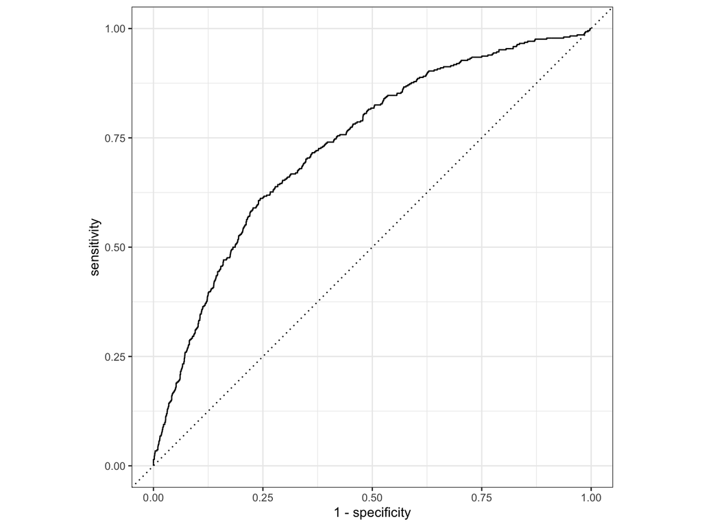

```r
flights_pred_lr_mod %>%
  roc_curve(truth = arr_delay,
            .pred_late) %>%
  autoplot()
```

## 8.2 AUC

Similarly, `roc_auc()` estimates the area under the curve:

```r
flights_pred_lr_mod %>%
  roc_auc(truth = arr_delay, .pred_late)
```

| .metric | .estimator | .estimate |
| --- | --- | --- |
| roc_auc | binary | 0.7329423 |

## 8.3 Metrics

Use the metrics() function to measure the performance of the model. It will automatically choose metrics appropriate for a given type of model. The function expects a tibble that contains the actual results (truth) and what the model predicted (estimate).

```r
flights_fit_lr_mode %>%
  predict(test_data) %>%
  bind_cols(test_data) %>%
  metrics(truth = arr_delay,
          estimate = .pred_class)
```

| .metric | .estimator | .estimate |
| --- | --- | --- |
| accuracy | binary | 0.8300000 |
| kap | binary | 0.1262594 |

## 8.4 Recall

```r
flights_fit_lr_mode %>%
  predict(test_data) %>%
    bind_cols(test_data) %>%
  recall(truth = arr_delay,
          estimate = .pred_class)
```

| .metric | .estimator | .estimate |
| --- | --- | --- |
| recall | binary | 0.118932 |

## 8.5 Precision

```r
flights_fit_lr_mode %>%
  predict(test_data) %>%
    bind_cols(test_data) %>%
  precision(truth = arr_delay,
          estimate = .pred_class)
```

| .metric | .estimator | .estimate |
| --- | --- | --- |
| precision | binary | 0.4414414 |